# Populate indicators using data for Hessequa Atlas Area

Katelyn Faulkner

2025-04-14

```r
# Load packages
library(tidyverse) # Data wrangling and visualisation
library(here)      # Relative paths
library(sf)        # Work with spatial data
library(b3gbi)     # Indicators
```

# Goal

Populate indicators using structured data of the Hessequa systematic atlasing subproject of the “Southern African Bird Atlas Project 2” (SABAP2).

Populate indicators using unstructured data of the Hessequa Atlas Area

Structured and unstructured data were prepared at both QDGC and pentad scales. Analysis at both scales below

# Load pentad scale data

## Structured data

The SABAP2 data were prepared and stored as a geopackage file in *./data/interim*.

We read in the dataset.

```r
# Data path
data_path <- here::here("data", "interim")
```

```r
# Read SABAP2 Hessequa atlas area bird data (5min x 5 min/ 8.2 km x 8.2 km)
SABAP2HAAinterim <- read_sf(file.path(data_path, "SABAP2_Pentad_HAA_data.gpkg"))

# Explore dataframe
glimpse(SABAP2HAAinterim)
```

```
## Rows: 102,232
## Columns: 239
## $ pentad                              <chr> "3355_2045", "3355_2045", "3355_20…
## $ `2015`                              <dbl> 6, 6, 6, 6, 6, 6, 6, 6, 6, 6, 6, 6…
## $ `2016`                              <dbl> 8, 8, 8, 8, 8, 8, 8, 8, 8, 8, 8, 8…
## $ `2017`                              <dbl> 13, 13, 13, 13, 13, 13, 13, 13, 13…
## $ `2018`                              <dbl> 8, 8, 8, 8, 8, 8, 8, 8, 8, 8, 8, 8…
## $ `2019`                              <dbl> 13, 13, 13, 13, 13, 13, 13, 13, 13…
## $ `2020`                              <dbl> 10, 10, 10, 10, 10, 10, 10, 10, 10…
## $ `2021`                              <dbl> 9, 9, 9, 9, 9, 9, 9, 9, 9, 9, 9, 9…
## $ `2022`                              <dbl> 11, 11, 11, 11, 11, 11, 11, 11, 11…
## $ `2023`                              <dbl> 8, 8, 8, 8, 8, 8, 8, 8, 8, 8, 8, 8…
## $ `2024`                              <dbl> 5, 5, 5, 5, 5, 5, 5, 5, 5, 5, 5, 5…
## $ format                              <chr> "geoJSON", "geoJSON", "geoJSON", "…
## $ fullprotocol                        <dbl> 91, 91, 91, 91, 91, 91, 91, 91, 91…
```

[output cut: 226 more lines]

## Unstructured data cube

Unstructured data from GBIF were prepared and stored as a geopackage file in *./data/interim*.

We read in the dataset.

```r
# Read unstructured Hessequa atlas area bird data (5min x 5 min/ 8.2 km x 8.2 km)
UnstrucHAAinterim <- read_sf(file.path(data_path, "birdcube_Pentad_year_HAA.gpkg"))

# Explore dataframe
glimpse(UnstrucHAAinterim)
```

```
## Rows: 8,409
## Columns: 21
## $ pentad                           <chr> "3355_2045", "3355_2045", "3355_2045"…
## $ `2015`                           <dbl> 6, 6, 6, 6, 6, 6, 6, 6, 6, 6, 6, 6, 6…
## $ `2016`                           <dbl> 8, 8, 8, 8, 8, 8, 8, 8, 8, 8, 8, 8, 8…
## $ `2017`                           <dbl> 13, 13, 13, 13, 13, 13, 13, 13, 13, 1…
## $ `2018`                           <dbl> 8, 8, 8, 8, 8, 8, 8, 8, 8, 8, 8, 8, 8…
## $ `2019`                           <dbl> 13, 13, 13, 13, 13, 13, 13, 13, 13, 1…
## $ `2020`                           <dbl> 10, 10, 10, 10, 10, 10, 10, 10, 10, 1…
## $ `2021`                           <dbl> 9, 9, 9, 9, 9, 9, 9, 9, 9, 9, 9, 9, 9…
## $ `2022`                           <dbl> 11, 11, 11, 11, 11, 11, 11, 11, 11, 1…
## $ `2023`                           <dbl> 8, 8, 8, 8, 8, 8, 8, 8, 8, 8, 8, 8, 8…
## $ `2024`                           <dbl> 5, 5, 5, 5, 5, 5, 5, 5, 5, 5, 5, 5, 5…
## $ format                           <chr> "geoJSON", "geoJSON", "geoJSON", "geo…
## $ fullprotocol                     <dbl> 91, 91, 91, 91, 91, 91, 91, 91, 91, 9…
## $ qdgccode                         <chr> "E020S33DD", "E020S33DD", "E020S33DD"…
## $ family                           <chr> "Corvidae", "Corvidae", "Corvidae", "…
## $ speciesKey                       <dbl> 2482521, 2482521, 2482521, 2482521, 2…
## $ species                          <chr> "Corvus capensis", "Corvus capensis",…
## $ n                                <int> 2, 8, 2, 4, 11, 3, 3, 1, 3, 1, 1, 1, …
## $ mincoordinateuncertaintyinmeters <dbl> 1000, 1000, 1000, 1000, 1000, 1000, 1…
## $ year                             <dbl> 2016, 2017, 2018, 2020, 2021, 2022, 2…
## $ geom                             <POLYGON [°]> POLYGON ((20.75 -33.91667, ..…
```

# Prepare data for indicators

Structured data from SABAP2 for birds recorded in pentads of Hessequa Atlas Area (77) between 2015 and 2024.

It was noted that there were 2016 records where ‘species’ was NA. They were removed below.

Also of note is that there is a delay in data feeding into GBIF, and so data for 2024, and most of 2023 is not included in the dataset.

There also seems to be issues for the data for certain species feeding into GBIF (could be related to 2016 records above).

```r
# Drop geometry, removed records not identified to species level
SABAP2HAAGeom <-  SABAP2HAAinterim %>%
filter(!is.na(species))

SABAP2HAA <-  SABAP2HAAGeom %>% st_drop_geometry()

# Group by species, year and pentad
SABAP2HAAGrp <-SABAP2HAA %>%
   group_by(species, year, pentad, speciesKey) %>%
    summarise(n = n())
glimpse(SABAP2HAAGrp)
```

```
## Rows: 45,777
## Columns: 5
## Groups: species, year, pentad [45,777]
## $ species    <chr> "Accipiter melanoleucus", "Accipiter melanoleucus", "Accipi…
## $ year       <dbl> 2015, 2015, 2015, 2016, 2016, 2016, 2016, 2016, 2016, 2016,…
## $ pentad     <chr> "3400_2100", "3405_2100", "3405_2115", "3400_2045", "3405_2…
## $ speciesKey <dbl> 2480631, 2480631, 2480631, 2480631, 2480631, 2480631, 24806…
## $ n          <int> 1, 1, 1, 1, 2, 2, 1, 1, 1, 1, 1, 1, 1, 4, 1, 2, 1, 1, 1, 1,…
```

Unstructured data from GBIF for birds recorded in pentads of Hessequa Atlas Area (77) between 2015 and 2024.

Note delays in data feeding into GBIF mean that the data for 2024 is not complete.

There were also 50 species in the unstructured data that were not in the SABAP2 data. This was due to various issues, including missidentifications, or potential issues with the data for these species feeding into GBIF.

```r
# Remove geometry
UnstrucHAA<- UnstrucHAAinterim %>%
  st_drop_geometry()
```

```r
# species recorded in sabap2
studied_spec <- unique(SABAP2HAA$species) %>%
  na.omit()

UnstrucHAAsppGeom <- UnstrucHAAinterim %>%
  filter(species %in% studied_spec)

UnstrucHAAspp <- UnstrucHAAsppGeom %>%
  st_drop_geometry()
```

# Indicators

The indicators have been populated including/excluding species in unstructured data not included in SABAP2

## Unstructured data

### Period 2015-2024 (all species)

```r
# Process cube
HAAunstruc <- process_cube(UnstrucHAA, grid_type = 'custom', first_year = '2015', cols_year =  'year', cols_cellCode = 'pentad', cols_occurrences = 'n',  cols_minCoordinateUncertaintyInMeters
= 'mincoordinateUncertaintyInMeters', cols_familyCount = 'familycount')
```

### Observed richness

```r
map_obs_rich_HAA <- obs_richness_map(HAAunstruc, cell_size = 0.08333333, level = "cube", region = "South Africa", ne_scale = "medium")
plot(map_obs_rich_HAA)
```

Above will not work as grid (pentads) is custom, cannot map results. Below mapped richness using other methods.

```r
RichFullrange<-range(0,300)
```

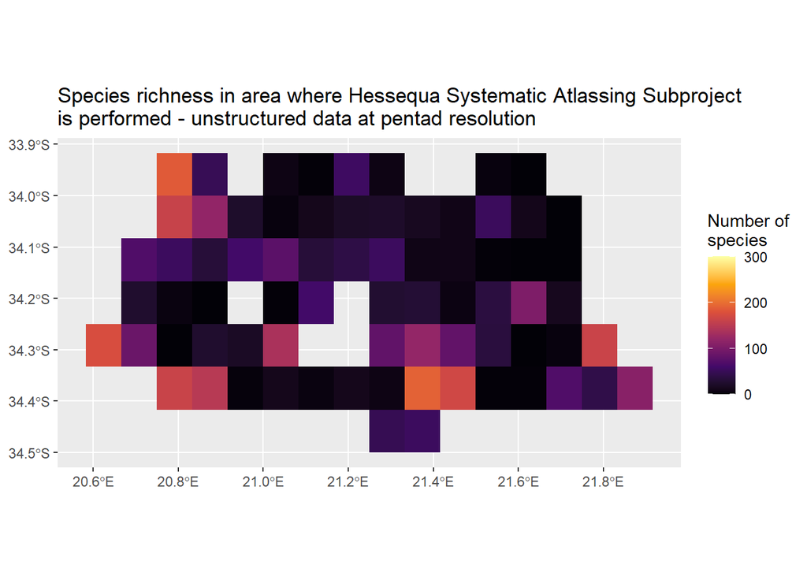

```r
UnstrucHAAinterim %>% group_by(pentad) %>%
              summarise(n_species = n_distinct(species), .groups = "drop") %>%
  ggplot() +
    geom_sf(aes(fill = n_species), col = alpha("white", 0)) +
  scale_fill_viridis_c(option = "inferno", name = "Number of\nspecies", limits = RichFullrange) +
  ggtitle("Species richness in area where Hessequa Systematic Atlassing Subproject\nis performed - unstructured data at pentad resolution")
```

Change over time

```r
ts_map_obs_rich_HAA <- obs_richness_ts(HAAunstruc, cell_size = 0.08333333, level = "cube", region = "South Africa", ne_scale = "medium")
```

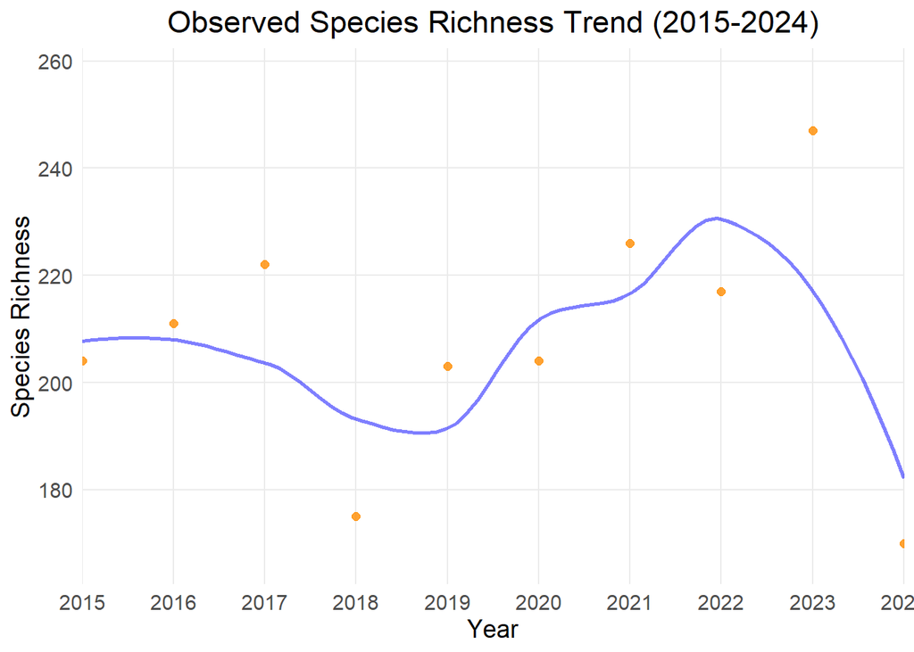

```r
plot(ts_map_obs_rich_HAA, y_expand = c(0.1, 0.2))
```

### Number of records

```r
RecFullrangePen<-range(0,13500)
```

```r
map_obs_HAA <- total_occ_map(HAAunstruc, cell_size = 0.08333333, level = "cube", region = "South Africa", ne_scale = "medium")
plot(map_obs_HAA)
```

Above will not work as grid (pentads) is custom, cannot map results.

Below mapped records using other methods.

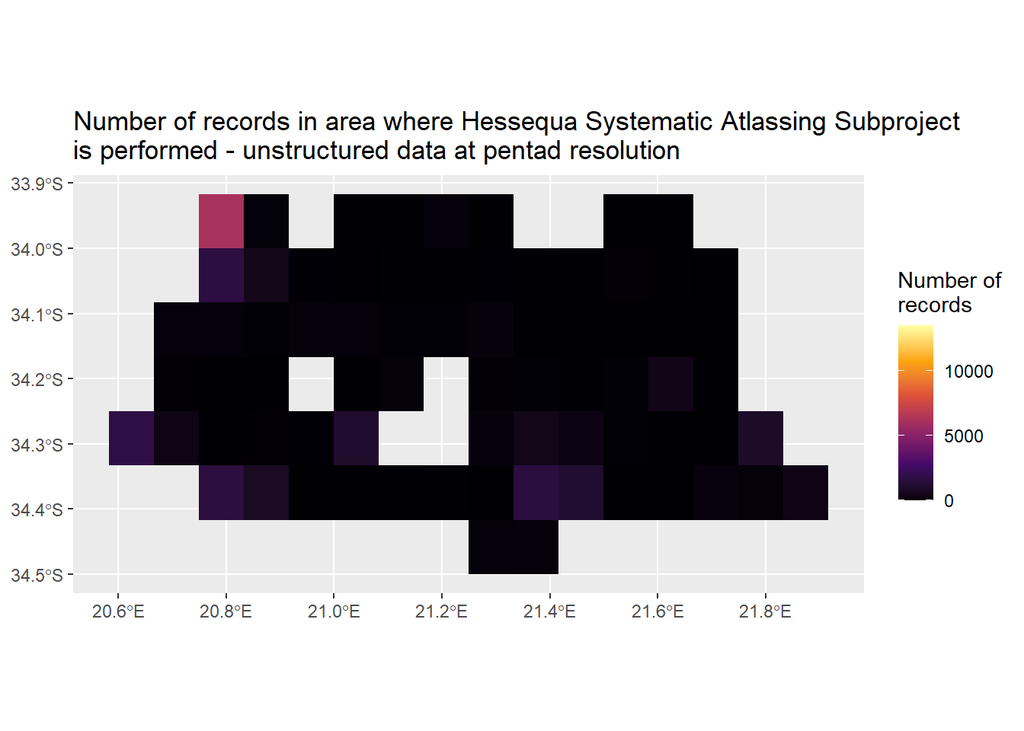

```r
UnstrucHAAinterim %>% group_by(pentad) %>%
              summarise(n_rec = sum(n), .groups = "drop") %>%
  ggplot() +
    geom_sf(aes(fill = n_rec), col = alpha("white", 0)) +
    scale_fill_viridis_c(option = "inferno", name = "Number of\nrecords", limits = RecFullrangePen) +
    ggtitle("Number of records in area where Hessequa Systematic Atlassing Subproject\nis performed - unstructured data at pentad resolution")
```

Change over time

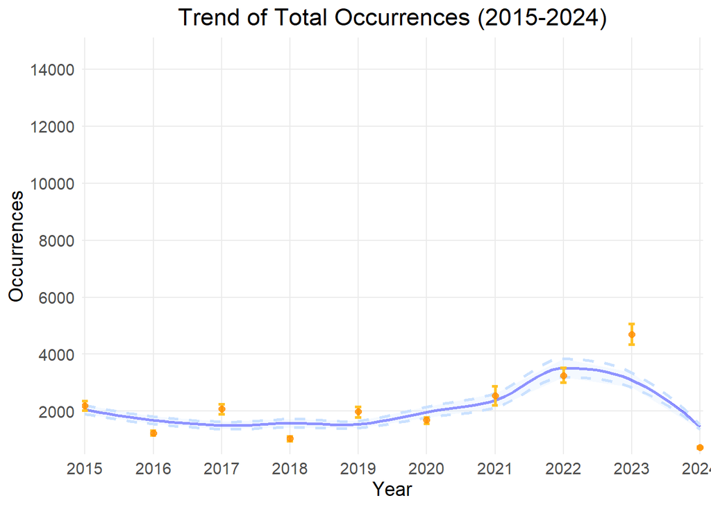

```r
ts_obs_HAA <- total_occ_ts(HAAunstruc, cell_size = 0.08333333, level = "cube", region = "South Africa", ne_scale = "medium")
plot(ts_obs_HAA, y_expand = c(0.05, 2.3))
```

### Period 2015-2024 (SABAP2 species)

```r
# Process cube
HAAunstrucSpp <- process_cube(UnstrucHAAspp, grid_type = 'custom', first_year = '2015', cols_year =  'year', cols_cellCode = 'pentad', cols_occurrences = 'n',  cols_minCoordinateUncertaintyInMeters
= 'mincoordinateUncertaintyInMeters', cols_familyCount = 'familycount')
```

### Observed richness

```r
map_obs_rich_HAA <- obs_richness_map(HAAunstrucSpp, cell_size = 0.08333333, level = "cube", region = "South Africa", ne_scale = "medium")
plot(map_obs_rich_HAA)
```

Above will not work as grid (pentads) is custom, cannot map results. Below mapped richness using other methods.

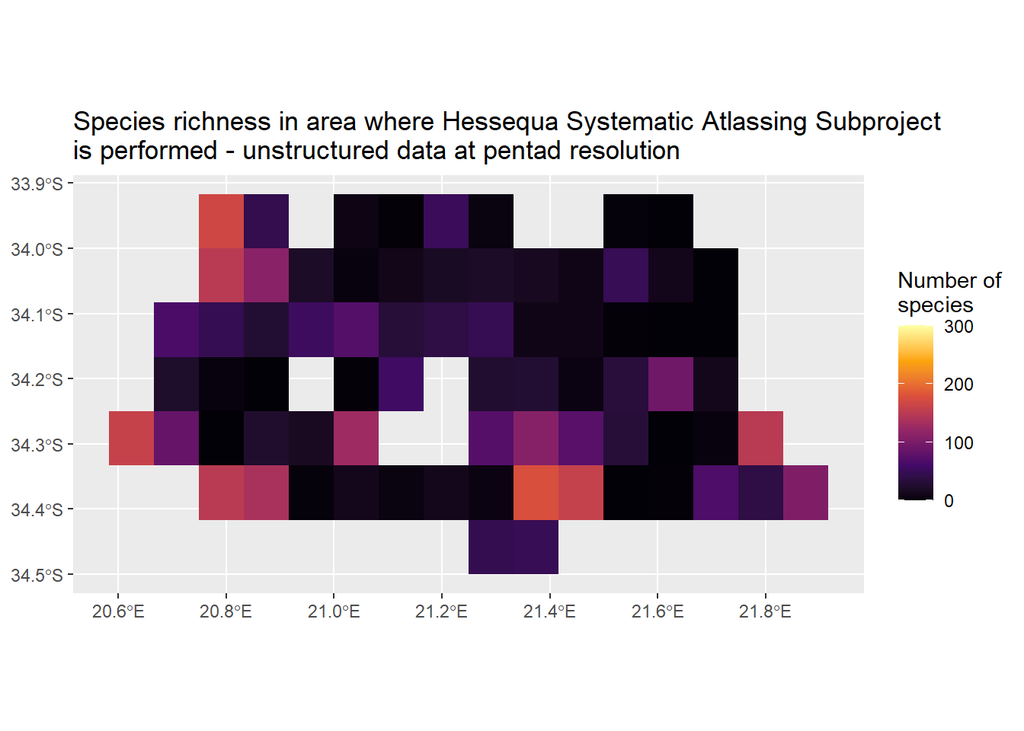

```r
UnstrucHAAsppGeom %>% group_by(pentad) %>%
              summarise(n_species = n_distinct(species), .groups = "drop") %>%
  ggplot() +
    geom_sf(aes(fill = n_species), col = alpha("white", 0)) +
    scale_fill_viridis_c(option = "inferno", name = "Number of\nspecies", limits = RichFullrange) +
    ggtitle("Species richness in area where Hessequa Systematic Atlassing Subproject\nis performed - unstructured data at pentad resolution")
```

Change over time

```r
ts_map_obs_rich_HAA <- obs_richness_ts(HAAunstrucSpp, cell_size = 0.08333333, level = "cube", region = "South Africa", ne_scale = "medium")
```

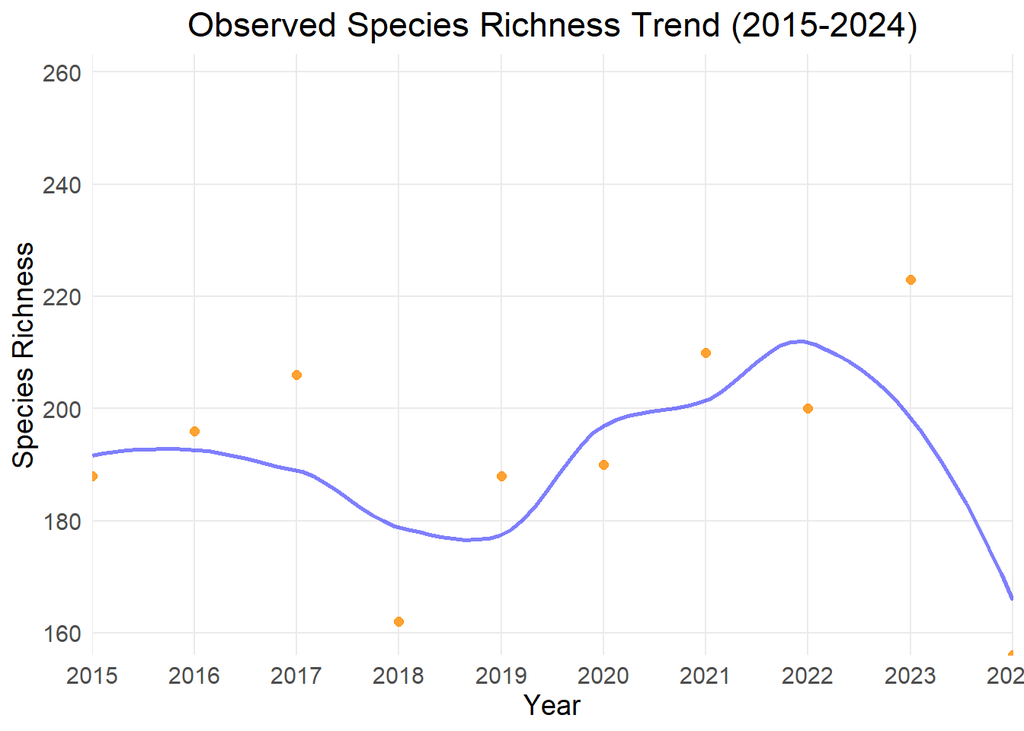

```r
plot(ts_map_obs_rich_HAA, y_expand = c(0, 0.6))
```

### Number of records

```r
map_obs_HAA <- total_occ_map(HAAunstrucSpp, cell_size = 0.08333333, level = "cube", region = "South Africa", ne_scale = "medium")
plot(map_obs_HAA)
```

Above will not work as grid (pentads) is custom, cannot map results but can look at change over time

Below mapped records using other methods.

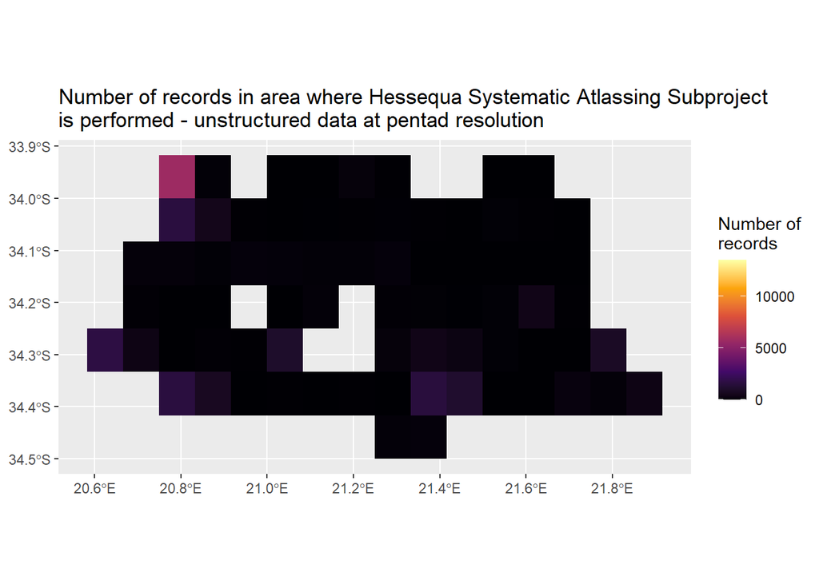

```r
UnstrucHAAsppGeom %>% group_by(pentad) %>%
              summarise(n_rec = sum(n), .groups = "drop") %>%
  ggplot() +
    geom_sf(aes(fill = n_rec), col = alpha("white", 0)) +
    scale_fill_viridis_c(option = "inferno", name = "Number of\nrecords", limits = RecFullrangePen) +
    ggtitle("Number of records in area where Hessequa Systematic Atlassing Subproject\nis performed - unstructured data at pentad resolution")
```

Change over time

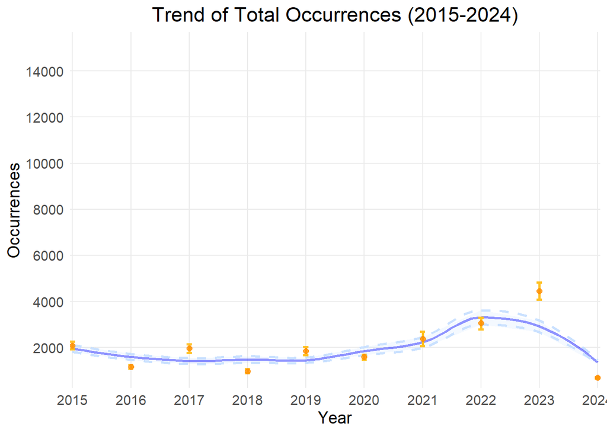

```r
ts_obs_HAA<- total_occ_ts(HAAunstrucSpp, cell_size = 0.08333333, level = "cube", region = "South Africa", ne_scale = "medium")
plot(ts_obs_HAA, y_expand = c(0.1, 2.6))
```

## Structured SABAP2 data (2015-2024)

```r
# Process cube
HAASABAP2 <- process_cube(SABAP2HAAGrp, grid_type = 'custom', first_year = '2015', cols_year =  'year', cols_cellCode = 'pentad', cols_occurrences = 'n')
```

### Observed richness

```r
map_obs_rich_SABAP2 <- obs_richness_map(HAASABAP2, cell_size = 0.08333333, level = "cube", region = "South Africa", ne_scale = "medium")
plot(map_obs_rich_SABAP2)
```

Above will not work as grid (pentads) is custom, cannot map results. Below mapped richness using other methods.

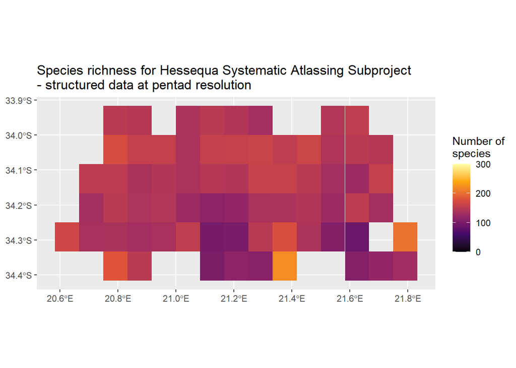

```r
SABAP2HAAGeom %>% group_by(pentad) %>%
              summarise(n_species = n_distinct(species), .groups = "drop") %>%
  ggplot() +
    geom_sf(aes(fill = n_species), col = alpha("white", 0)) +
    scale_fill_viridis_c(option = "inferno", name = "Number of\nspecies", limits = RichFullrange) +
    ggtitle("Species richness for Hessequa Systematic Atlassing Subproject\n- structured data at pentad resolution")
```

change over time

```r
ts_obs_rich_SABAP2 <- obs_richness_ts(HAASABAP2, cell_size = 0.08333333, level = "cube", region = "South Africa", ne_scale = "medium")
```

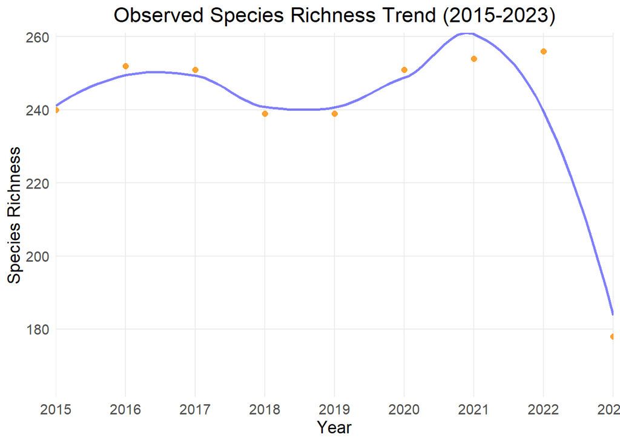

```r
plot(ts_obs_rich_SABAP2, y_expand = c(0.2, 0))
```

### Number of records

```r
map_obs_SABAP2 <- total_occ_map(HAASABAP2, cell_size = 0.08333333, level = "cube", region = "South Africa", ne_scale = "medium")
plot(map_obs_SABAP2)
```

Above will not work as grid (pentads) is custom, cannot map results but can look at change over time

Below mapped records using other methods.

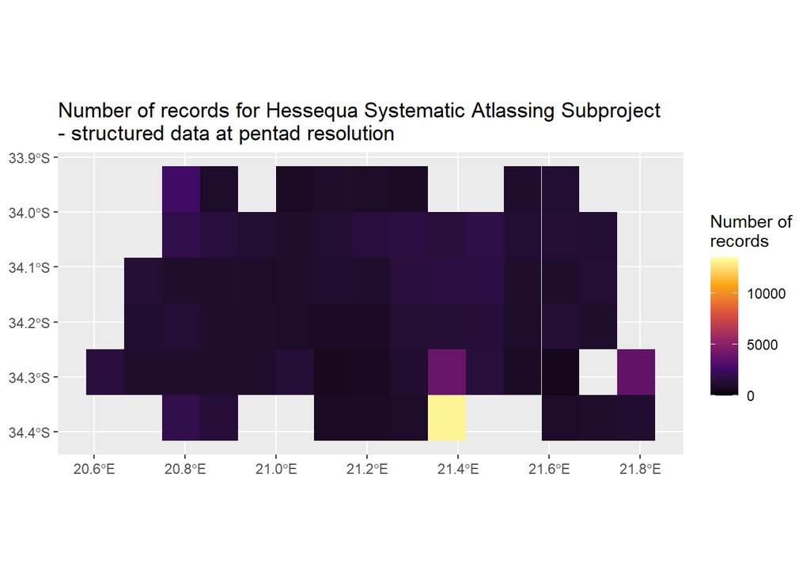

```r
SABAP2HAAGeom %>% group_by(pentad) %>%
              summarise(n_rec = n(), .groups = "drop") %>%
  ggplot() +
    geom_sf(aes(fill = n_rec), col = alpha("white", 0)) +
    scale_fill_viridis_c(option = "inferno", name = "Number of\nrecords", limits = RecFullrangePen) +
    ggtitle("Number of records for Hessequa Systematic Atlassing Subproject\n- structured data at pentad resolution")
```

Change over time

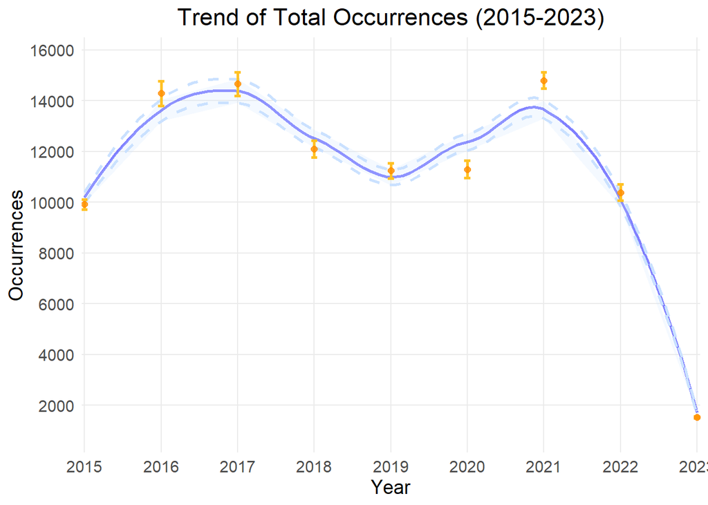

```r
ts_obs_SABAP2 <- total_occ_ts(HAASABAP2, cell_size = 0.08333333, level = "cube", region = "South Africa", ne_scale = "medium")
plot(ts_obs_SABAP2, y_expand = c(0.1, 0.1))
```

# Load QDGC scale data

## Structured data

### Occurrence data

The SABAP2 data were prepared and stored as a geopackage file in *./data/interim*.

We read in the dataset.

```r
# Read SABAP2 Hessequa atlas area bird data
SABAP2HAAQDGCinterim <- read_sf(file.path(data_path, "SABAP2_QDGC_HAA_data.gpkg"))

# Explore dataframe
glimpse(SABAP2HAAQDGCinterim)
```

```
## Rows: 102,232
## Columns: 231
## $ qdgc                                <chr> "E020S34BC", "E020S34BC", "E020S34…
## $ level_qdgc                          <int> 2, 2, 2, 2, 2, 2, 2, 2, 2, 2, 2, 2…
## $ cellsize_degrees                    <dbl> 0.25, 0.25, 0.25, 0.25, 0.25, 0.25…
## $ lon_center                          <dbl> 20.625, 20.625, 20.625, 20.625, 20…
## $ lat_center                          <dbl> -34.375, -34.375, -34.375, -34.375…
## $ area_km2                            <dbl> 637.6817, 637.6817, 637.6817, 637.…
## $ gbifID                              <dbl> 2346013328, 2346206362, 2346937068…
## $ accessRights                        <lgl> NA, NA, NA, NA, NA, NA, NA, NA, NA…
## $ bibliographicCitation               <lgl> NA, NA, NA, NA, NA, NA, NA, NA, NA…
## $ language                            <lgl> NA, NA, NA, NA, NA, NA, NA, NA, NA…
## $ license                             <chr> "CC_BY_4_0", "CC_BY_4_0", "CC_BY_4…
## $ modified                            <lgl> NA, NA, NA, NA, NA, NA, NA, NA, NA…
## $ publisher                           <chr> "FitzPatrick Institute of African …
```

[output cut: 218 more lines]

## Unstructured data cube

Unstructured data from GBIF were prepared and stored as a geopackage file in *./data/interim*.

We read in the dataset.

```r
# Read unstructured Hessequa atlas area bird data
UnstrucHAAQDGCinterim <- read_sf(file.path(data_path, "birdcube_QDGC_year_HAA.gpkg"))

# Explore dataframe
glimpse(UnstrucHAAQDGCinterim)
```

```
## Rows: 9,125
## Columns: 14
## $ qdgc                             <chr> "E020S34BC", "E020S34BC", "E020S34BC"…
## $ level_qdgc                       <int> 2, 2, 2, 2, 2, 2, 2, 2, 2, 2, 2, 2, 2…
## $ cellsize_degrees                 <dbl> 0.25, 0.25, 0.25, 0.25, 0.25, 0.25, 0…
## $ lon_center                       <dbl> 20.625, 20.625, 20.625, 20.625, 20.62…
## $ lat_center                       <dbl> -34.375, -34.375, -34.375, -34.375, -…
## $ area_km2                         <dbl> 637.6817, 637.6817, 637.6817, 637.681…
## $ year                             <dbl> 2015, 2015, 2015, 2015, 2015, 2015, 2…
## $ specieskey                       <dbl> 2473341, 2473807, 2474156, 2474381, 2…
## $ species                          <chr> "Numida meleagris", "Pternistis capen…
## $ family                           <chr> "Numididae", "Phasianidae", "Phasiani…
## $ n                                <dbl> 20, 19, 7, 20, 12, 4, 2, 30, 1, 10, 5…
## $ mincoordinateuncertaintyinmeters <dbl> 488, 1000, 1000, 1000, 122, 1000, 100…
## $ familycount                      <dbl> 28999, 36022, 36022, 57131, 8248, 824…
## $ geom                             <MULTIPOLYGON [°]> MULTIPOLYGON (((20.5 -34…
```

# Prepare data for indicators

Structured data from SABAP2 for birds recorded in pentads of Hessequa Atlas Area (77) between 2015 and 2024. These data have been converted to QDGC. 15 QDGC cover the area.

It was noted that there were records where species was NA. They were removed below. There may be an issue with the data for certain species flowing into GBIF from SABAP2.

There is also a delay for data into GBIF, so data for all of 2024 and most of 2023 not included in dataset.

```r
# Drop geometry, removed records not identified to species level
SABAP2HAAQDGCGeom <-  SABAP2HAAQDGCinterim %>%
  filter(!is.na(species))

SABAP2HAAQDGC <-  SABAP2HAAQDGCGeom %>% st_drop_geometry()

# Group by species, year and pentad
SABAP2HAAQDGCGrp <-SABAP2HAAQDGC %>%
   group_by(species, year, qdgc, speciesKey) %>%
    summarise(n = n())
glimpse(SABAP2HAAQDGCGrp)
```

```
## Rows: 16,008
## Columns: 5
## Groups: species, year, qdgc [16,008]
## $ species    <chr> "Accipiter melanoleucus", "Accipiter melanoleucus", "Accipi…
## $ year       <dbl> 2015, 2015, 2016, 2016, 2016, 2016, 2016, 2016, 2016, 2017,…
## $ qdgc       <chr> "E021S34AA", "E021S34AB", "E020S34BB", "E020S34BD", "E021S3…
## $ speciesKey <dbl> 2480631, 2480631, 2480631, 2480631, 2480631, 2480631, 24806…
## $ n          <int> 2, 1, 3, 1, 2, 2, 1, 2, 1, 4, 3, 2, 1, 2, 5, 1, 1, 1, 1, 1,…
```

Unstructured data from GBIF for birds recorded in pentads of Hessequa Atlas Area (77) between 2015 and 2024. These data have been converted to QDGC scale. There are 15 QDGC in the area.

It was noted that there were a number of species included in the unstructured data that were not in the structured data. This was for a number of reasons including likely misidentifications, and also as for some species SABAP2 data does not seem to be flowing to GBIF.

Due to delays in data flowing into GBIF the data for 2024 are not complete.

```r
# Remove NAs and geometry
UnstrucHAAQDGC<- UnstrucHAAQDGCinterim %>%
  st_drop_geometry()
```

```r
# species recorded in sabap2
studied_spec <- unique(SABAP2HAAQDGC$species) %>%
  na.omit()

UnstrucHAAQDGCsppGeom <- UnstrucHAAQDGCinterim %>%
  filter(species %in% studied_spec)

UnstrucHAAQDGCspp <- UnstrucHAAQDGCsppGeom %>%
  st_drop_geometry()
```

# Indicators

The indicators have been populated including/excluding species in unstructured data not included in SABAP2

## Unstructured data

### Period 2015-2024 (all species)

```r
# Process cube
HAAunstrucQDGCproc <- process_cube(UnstrucHAAQDGC, grid_type = 'eqdgc', first_year = '2015', cols_year =  'year', cols_cellCode = 'qdgc', cols_occurrences = 'n',  cols_minCoordinateUncertaintyInMeters
= 'mincoordinateuncertaintyinmeters', cols_familyCount = 'familycount', cols_speciesKey = 'specieskey')
```

### Observed richness

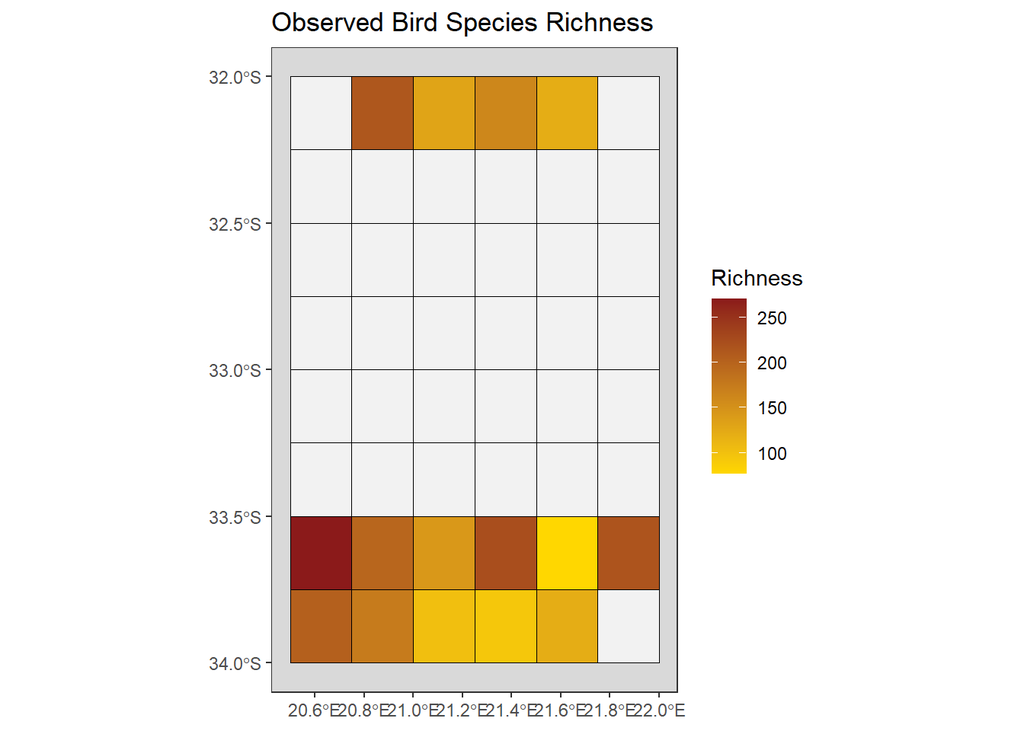

```r
map_obs_rich_HAA_QDGC <- obs_richness_map(HAAunstrucQDGCproc, cell_size = 0.25, level = "cube", region = "South Africa", ne_scale = "medium")
plot(map_obs_rich_HAA_QDGC, title = "Observed Bird Species Richness")
```

Plots, but oddly. Possible issue with grid package uses.

Below mapped richness using other methods.

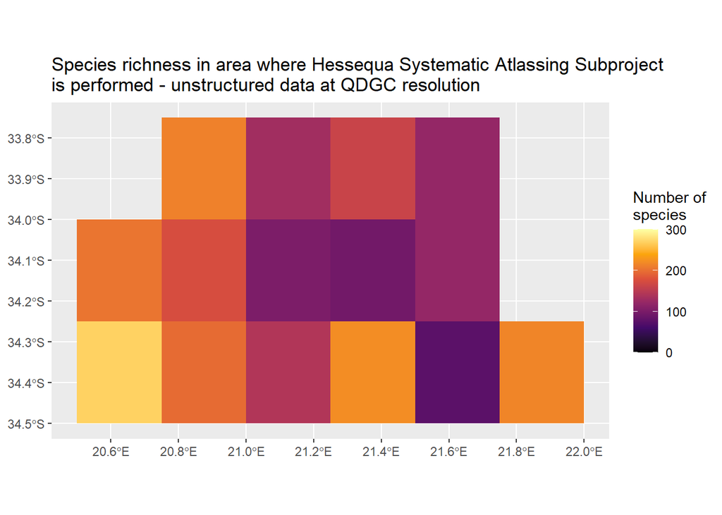

```r
UnstrucHAAQDGCinterim %>% group_by(qdgc) %>%
  summarise(n_species = n_distinct(species), .groups = "drop") %>%
  ggplot() +
  geom_sf(aes(fill = n_species), col = alpha("white", 0)) +
  scale_fill_viridis_c(option = "inferno", name = "Number of\nspecies", limits = RichFullrange) +
  ggtitle("Species richness in area where Hessequa Systematic Atlassing Subproject\nis performed - unstructured data at QDGC resolution")
```

Changes over time

```r
ts_map_obs_rich_HAA_QDGC <- obs_richness_ts(HAAunstrucQDGCproc, cell_size = 0.25, level = "cube", region = "South Africa", ne_scale = "medium")
```

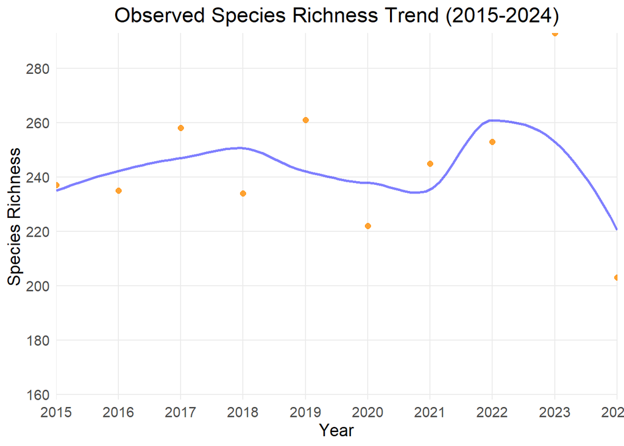

```r
plot(ts_map_obs_rich_HAA_QDGC, y_expand = c(0.5, 0))
```

### Number of records

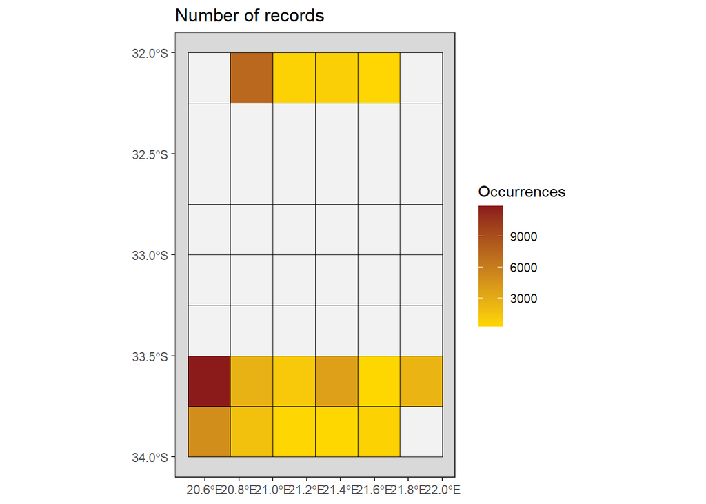

```r
map_obs_HAA_QDGC <- total_occ_map(HAAunstrucQDGCproc, cell_size = 0.25, level = "cube", region = "South Africa", ne_scale = "medium")
plot(map_obs_HAA_QDGC, title = "Number of records")
```

Plots, but oddly. Possible issue with grid package uses.

Below mapped number of records using other methods.

```r
RecFullrangeQDGC<-range(0,21000)
```

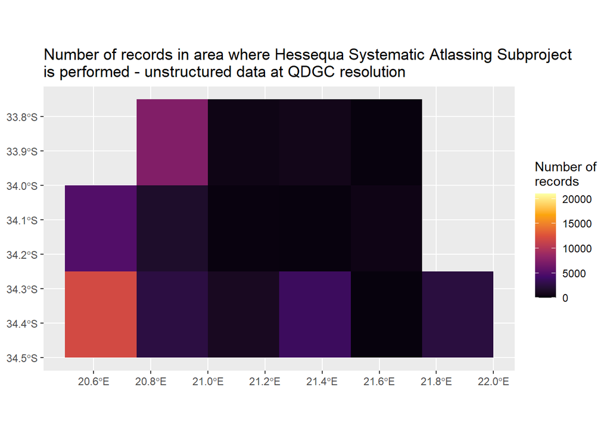

```r
UnstrucHAAQDGCinterim %>% group_by(qdgc) %>%
  summarise(n_rec = sum(n), .groups = "drop") %>%
  ggplot() +
  geom_sf(aes(fill = n_rec), col = alpha("white", 0)) +
  scale_fill_viridis_c(option = "inferno", name = "Number of\nrecords", limits = RecFullrangeQDGC) +
  ggtitle("Number of records in area where Hessequa Systematic Atlassing Subproject\nis performed - unstructured data at QDGC resolution")
```

Changes over time

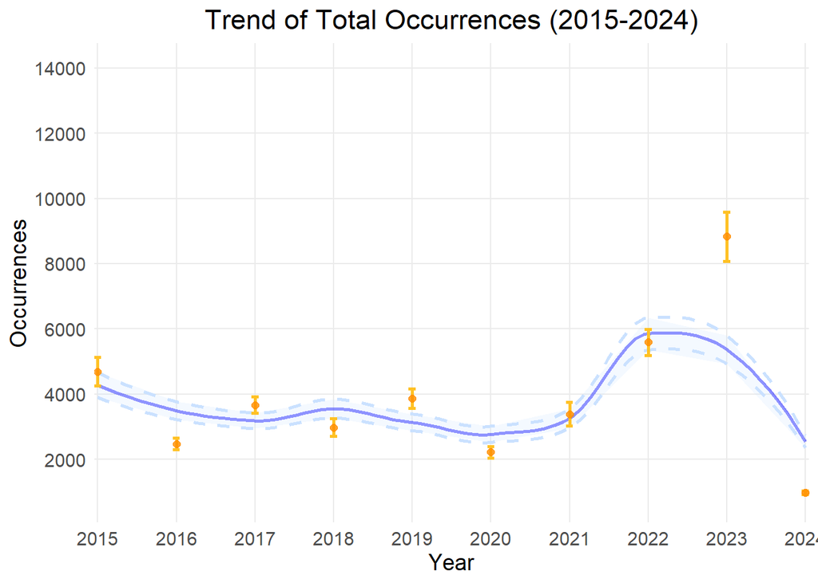

```r
ts_obs_HAA_QDGC <- total_occ_ts(HAAunstrucQDGCproc, cell_size = 0.25, level = "cube", region = "South Africa", ne_scale = "medium")
plot(ts_obs_HAA_QDGC,y_expand = c(0.1, 0.6))
```

### Period 2015-2024 (SABAP2 species)

```r
# Process cube
HAAunstrucQDGCsppproc <- process_cube(UnstrucHAAQDGCspp, grid_type = 'eqdgc', first_year = '2015', cols_year =  'year', cols_cellCode = 'qdgc', cols_occurrences = 'n',  cols_minCoordinateUncertaintyInMeters
= 'mincoordinateuncertaintyinmeters', cols_familyCount = 'familycount', cols_speciesKey = 'specieskey')
```

### Observed richness

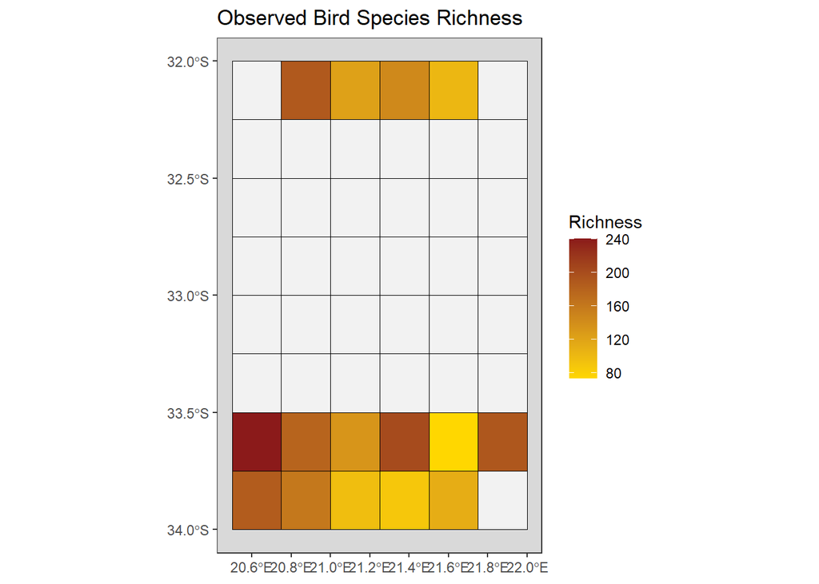

```r
map_obs_rich_HAA_QDGC <- obs_richness_map(HAAunstrucQDGCsppproc, cell_size = 0.25, level = "cube", region = "South Africa", ne_scale = "medium")
plot(map_obs_rich_HAA_QDGC, title = "Observed Bird Species Richness")
```

Plots, but oddly. Possible issue with grid package uses.

Below mapped richness using other methods.

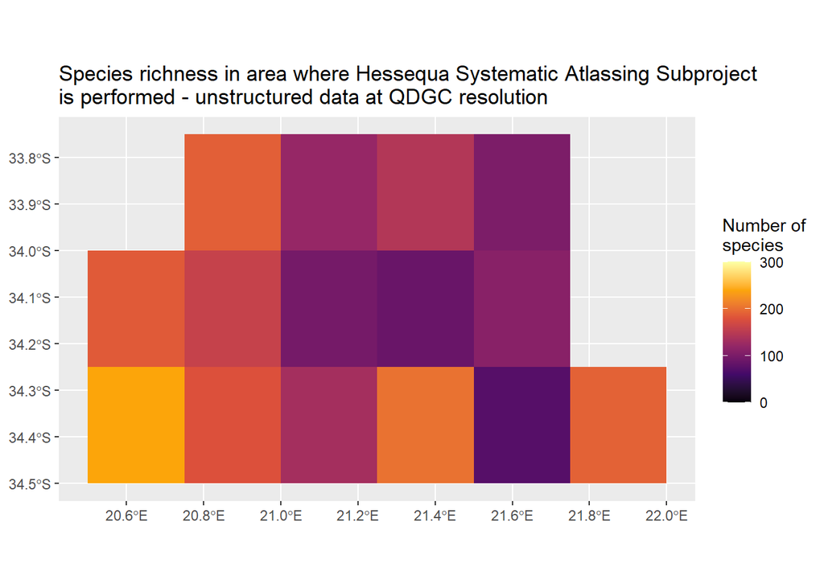

```r
UnstrucHAAQDGCsppGeom %>% group_by(qdgc) %>%
  summarise(n_species = n_distinct(species), .groups = "drop") %>%
  ggplot() +
  geom_sf(aes(fill = n_species), col = alpha("white", 0)) +
  scale_fill_viridis_c(option = "inferno", name = "Number of\nspecies", limits = RichFullrange) +
  ggtitle("Species richness in area where Hessequa Systematic Atlassing Subproject\nis performed - unstructured data at QDGC resolution")
```

Changes over time

```r
ts_map_obs_rich_HAA_QDGC <- obs_richness_ts(HAAunstrucQDGCsppproc, cell_size = 0.25, level = "cube", region = "South Africa", ne_scale = "medium")
```

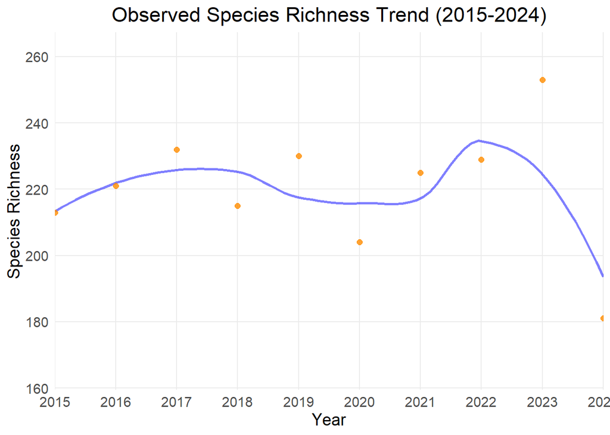

```r
plot(ts_map_obs_rich_HAA_QDGC, y_expand = c(0.3, 0.2))
```

### Number of records

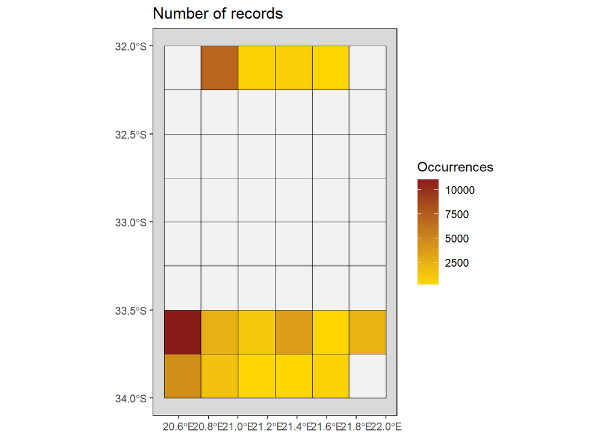

```r
map_obs_HAA_QDGC <- total_occ_map(HAAunstrucQDGCsppproc, cell_size = 0.25, level = "cube", region = "South Africa", ne_scale = "medium")
plot(map_obs_HAA_QDGC, title = "Number of records")
```

Plots, but oddly. Possible issue with grid package uses.

Below mapped number of records using other methods.

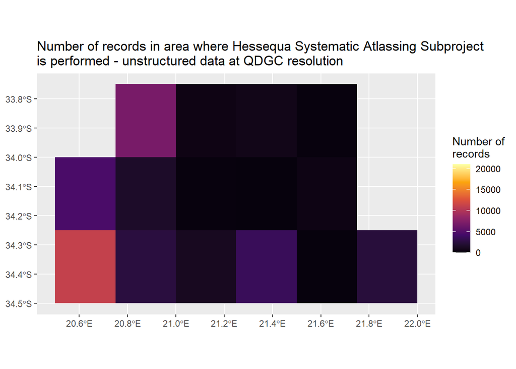

```r
UnstrucHAAQDGCsppGeom %>% group_by(qdgc) %>%
  summarise(n_rec = sum(n), .groups = "drop") %>%
  ggplot() +
  geom_sf(aes(fill = n_rec), col = alpha("white", 0)) +
  scale_fill_viridis_c(option = "inferno", name = "Number of\nrecords", limits = RecFullrangeQDGC) +
  ggtitle("Number of records in area where Hessequa Systematic Atlassing Subproject\nis performed - unstructured data at QDGC resolution")
```

Changes over time

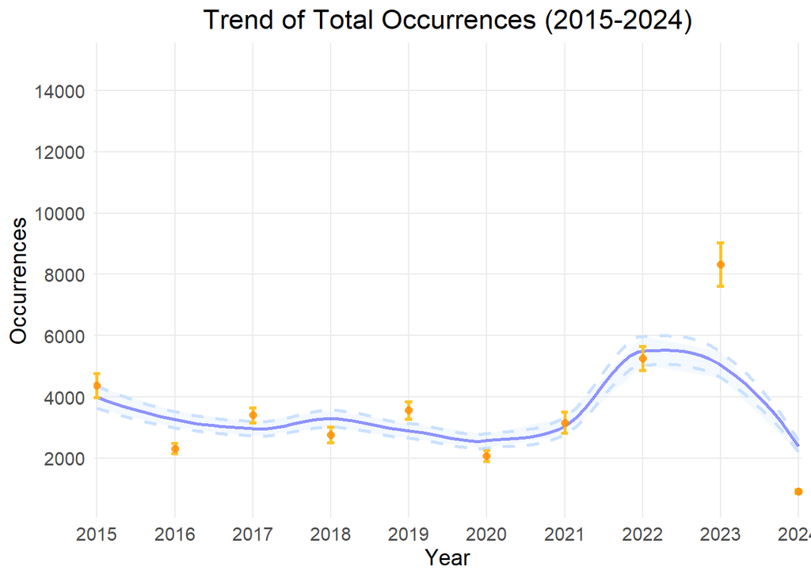

```r
ts_obs_HAA_QDGC <- total_occ_ts(HAAunstrucQDGCsppproc, cell_size = 0.25, level = "cube", region = "South Africa", ne_scale = "medium")
plot(ts_obs_HAA_QDGC, y_expand = c(0.1, 0.8))
```

## Structured SABAP2 data

```r
# Process cube
HAASABAP2QDGC <- process_cube(SABAP2HAAQDGCGrp, grid_type = 'eqdgc', first_year = '2015', cols_year =  'year', cols_cellCode = 'qdgc', cols_occurrences = 'n')
```

### Observed richness

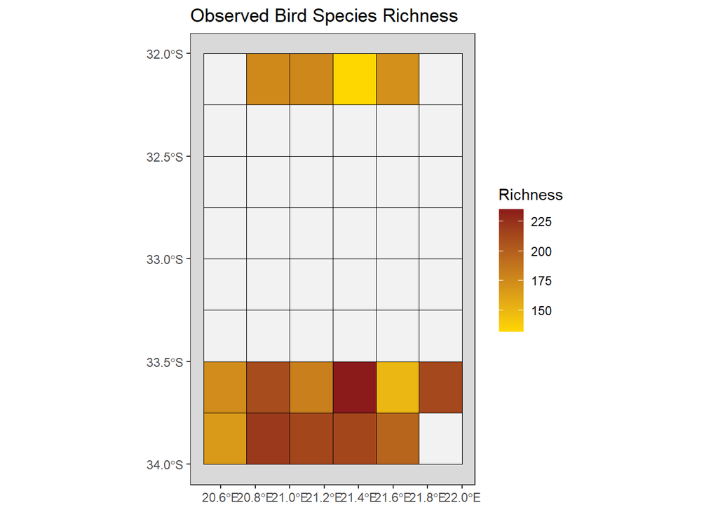

```r
map_obs_rich_SABAP2_QDGC <- obs_richness_map(HAASABAP2QDGC, cell_size = 0.25, level = "cube", region = "South Africa", ne_scale = "medium")
plot(map_obs_rich_SABAP2_QDGC, title = "Observed Bird Species Richness")
```

Plots, but oddly. Possible issue with grid package uses.

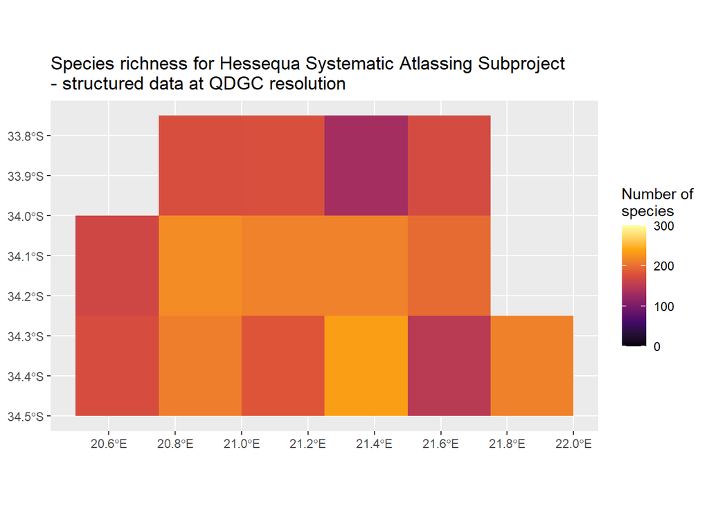

```r
SABAP2HAAQDGCGeom %>% group_by(qdgc) %>%
  summarise(n_species = n_distinct(species), .groups = "drop") %>%
  ggplot() +
  geom_sf(aes(fill = n_species), col = alpha("white", 0)) +
  scale_fill_viridis_c(option = "inferno", name = "Number of\nspecies", limits = RichFullrange) +
  ggtitle("Species richness for Hessequa Systematic Atlassing Subproject\n- structured data at QDGC resolution")
```

Changes over time

```r
ts_obs_rich_SABAP2_QDGC <- obs_richness_ts(HAASABAP2QDGC, cell_size = 0.25, level = "cube", region = "South Africa", ne_scale = "medium")
```

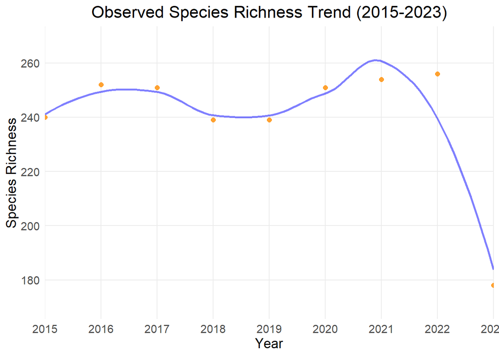

```r
plot(ts_obs_rich_SABAP2_QDGC, y_expand = c(0.15, 0.15))
```

### Number of records

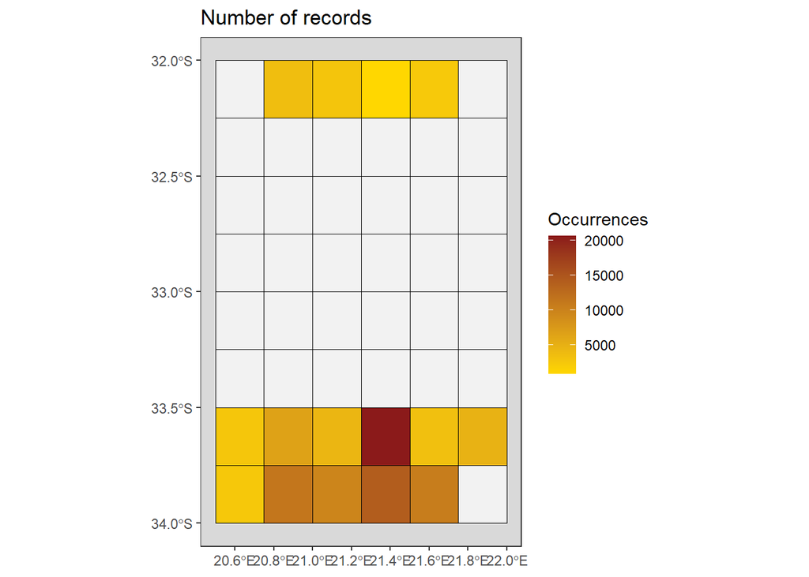

```r
map_obs_SABAP2_QDGC <- total_occ_map(HAASABAP2QDGC, cell_size = 0.25, level = "cube", region = "South Africa", ne_scale = "medium")
plot(map_obs_SABAP2_QDGC, title = "Number of records")
```

Plots, but oddly. Possible issue with grid package uses.

Below mapped number of records using other methods.

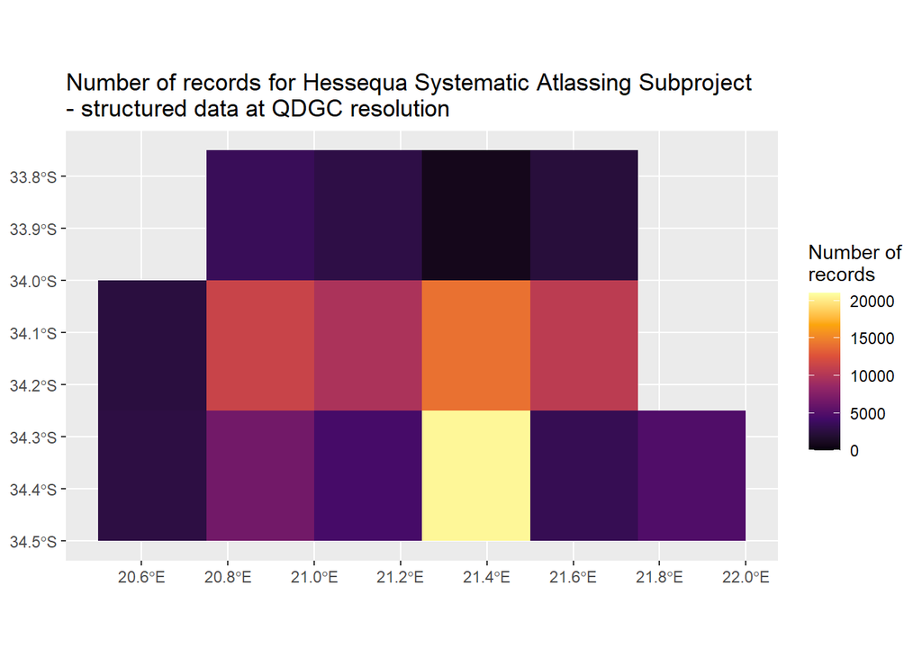

```r
SABAP2HAAQDGCGeom %>% group_by(qdgc) %>%
  summarise(n_rec = n(), .groups = "drop") %>%
  ggplot() +
  geom_sf(aes(fill = n_rec), col = alpha("white", 0)) +
  scale_fill_viridis_c(option = "inferno", name = "Number of\nrecords", limits = RecFullrangeQDGC) +
  ggtitle("Number of records for Hessequa Systematic Atlassing Subproject\n- structured data at QDGC resolution")
```

Changes over time

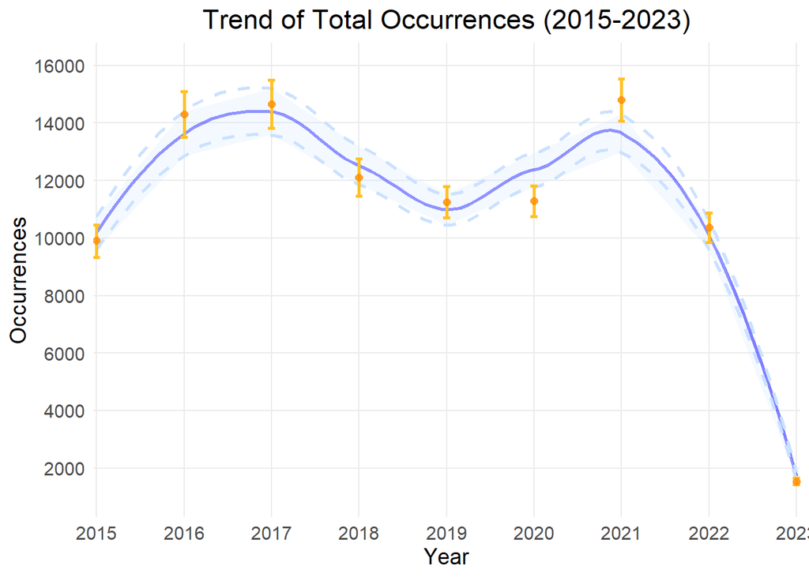

```r
ts_obs_SABAP2_QDGC <- total_occ_ts(HAASABAP2QDGC, cell_size = 0.25, level = "cube", region = "South Africa", ne_scale = "medium")
plot(ts_obs_SABAP2_QDGC, y_expand = c(0.08, 0.09))
```

### Species specific indicators

**Spilopelia senegalensis** - a species for which records have increased

#### Quarter-degree grid cell resolution

Maps of occurrence - unstructured data

```
## $`Spilopelia senegalensis`
```

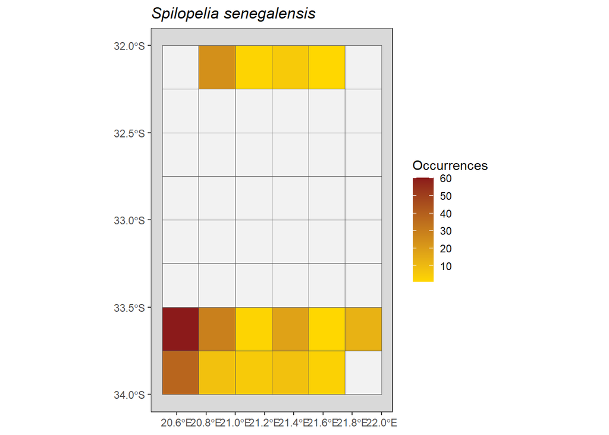

```r
map_spec_occ_unstruc_HAA_QDGC <- spec_occ_map(HAAunstrucQDGCproc, cell_size = 0.25, level = "cube", region = "South Africa", ne_scale = "medium")

plot(map_spec_occ_unstruc_HAA_QDGC, species = "Spilopelia senegalensis")
```

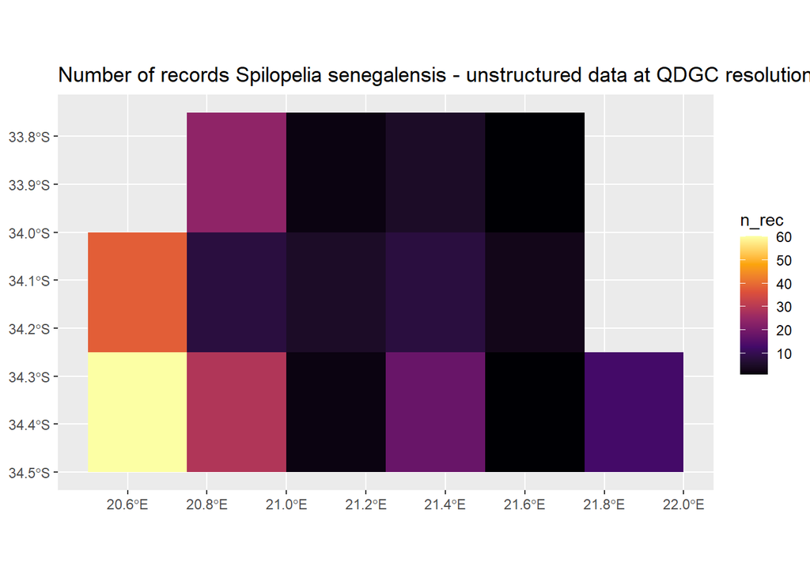

```r
UnstrucHAAQDGCinterim %>% filter(species == "Spilopelia senegalensis") %>% group_by(qdgc) %>%
  summarise(n_rec = sum(n), .groups = "drop") %>%
  ggplot() +
  geom_sf(aes(fill = n_rec), col = alpha("white", 0)) +
  scale_fill_viridis_c(option = "inferno") +
  ggtitle("Number of records Spilopelia senegalensis - unstructured data at QDGC resolution")
```

Time series of occurrence - unstructured data

```r
ts_spec_occ_unstruc_HAA_QDGC <- spec_occ_ts(HAAunstrucQDGCproc, cell_size = 0.25, level = "cube", region = "South Africa", ne_scale = "medium")
```

[output not shown]

[output cut: 55 more lines]